# Lab 8

Univariate Statistics with R

Three different activities this week! These may require a bit of thinking; we’ve tried to include enough information to help you find solutions, but `our’ solutions aren’t the only ones, obviously.

## A brief note on `with()`

You may have noticed a really useful function in the solutions for last weeks lab - the `with()` function. The way in which this function works is to allow you to specify a data frame that an expression uses and therefore not need to include it when specifying variables. See the following example:

```r
cor.test(schools$iq, schools$exam)
```

This command can be written as:

```r
with(schools, cor.test(iq, exam))
```

This is a nice trick that can make your code more readable and also save time and effort when you have an expression where you are referring to a data frame multiple times. Take this code which will print any values of the `iq` variable in a data frame called `schools` that are above 2.5 standard deviations from the mean:

```r
schools$iq[schools$iq > mean(schools$iq, na.rm = T) + 2.5 * sd(schools$iq, na.rm = T)]
```

This could be written as:

```r
with(schools, iq[iq > mean(iq, na.rm = T) + 2.5 * sd(iq, na.rm = T)])
```

`with()` is essentially a convenience function. Make use of it if you feel it produces more readable code and saves you precious time and typing energy!

## Last Week’s Linear Model

**Task 1:** Start by opening last week’s (Lab 7) project. Since we’re continuing to work on the same data, it’s easier to extend the same project.

**Task 2:** Re-run the code you ran last week to load and merge the school datasets.

Don’t have the relevant R code saved? That’s a problem. It really is important to save code, in scripts, when you use R, so that you (and others) can replicate work you’ve already done. Statistical analysis is as much a *process* as an *outcome*. For now we can overcome this by loading a version of the data that has been merged already - create a new script file now and in the first line, type the command `load(url("http://is.gd/tsktsk"))` and run it.

**Task 3:** Create a linear model and inspect it by typing the code below (my merged data is in `schools`; you may need to edit the code appropriately).

```r
model <- lm(exam ~ iq, data = schools)
summary(model)
```

**Tip:** Models may vary very slightly from person to person, depending which outliers you decided to remove, *etc*.

**Task 4:** Which is the intercept? Which is the slope? How can you interpret each of them?

**Task 5:** You may conclude that the intercept isn’t very meaningful! Create a new linear model, `model2`, with a more meaningful intercept. *(Take a look at slides 9 and 15 from this weeks lecture for some guidance with this)*

**Tip:** Arithmetic operators such as `+` and `-` have different meanings within a *formula* (the part which represents the relationship between variables, such as `exam ~ iq`. To ‘isolate’ arithmetic from the formula interpretation, use `I()`, so `exam ~ I(iq + 23)` means “`exam` is predicted by `iq + 23`”; `exam ~ iq + 23` means “`exam` is predicted by `iq` and the number `23`” (whatever that means!).

**Task 6:** What does the intercept of `model2` tell us? And the slope?

## Drawing lines in plots

Let’s take a little break from the linear model and talk about drawing lines. Since – as you’ve been repeatedly told – most of the statistics you’ll need is, in some form, a twist on the linear model, being able to do this is quite useful. Regression coefficients can sometimes get a little tricky to interpret (wait till we talk about logistic regression in Week 10) and visualising the model goes a long way to make the interpretation easier.

### Useful stuff to try first

**Task 7:** Create a blank canvas, like so:

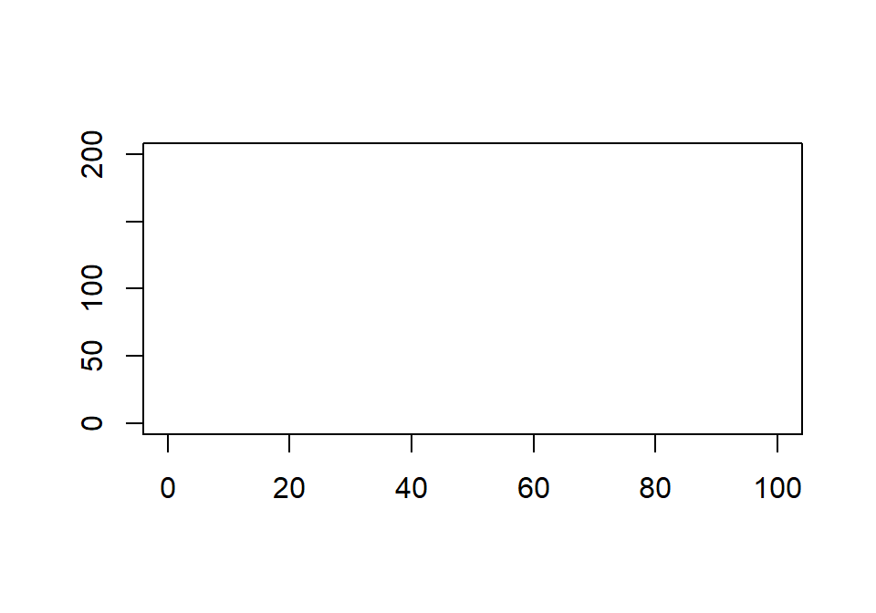

```r
plot(NULL, xlim = c(0, 100), ylim = c(0, 200), xlab = "", ylab = "")
```

```r
y <- 2 * x + rnorm(100, 10, 10) # rnorm adds noise to the relationship
```

**Task 10:** Now try drawing lines, connecting each point $(x, y)$ together using `lines()`. What will you get?

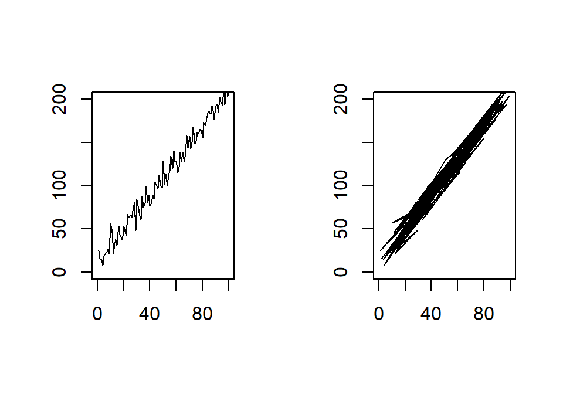

I hope you expected to get a plot similar to the one on the left but ended up with a bit of a mess like the right-hand side plot.

**Task 11:** Why do you think that is the case? *Hint:* Think [connect the dots](https://en.wikipedia.org/wiki/Connect_the_dots)…

The reason is that the lines join each point $(x, y)$ *in the order they appear in the vector*. Let’s look at a simple example:

```
  x y
1 2 3
2 1 6
3 3 8
```

**Task 12:** Take a pen and draw 3 points in the plot below corresponding to the [X, Y] coordinates from this data frame. Above the points write a number corresponding to the row of the [X, Y] pair in the data frame.

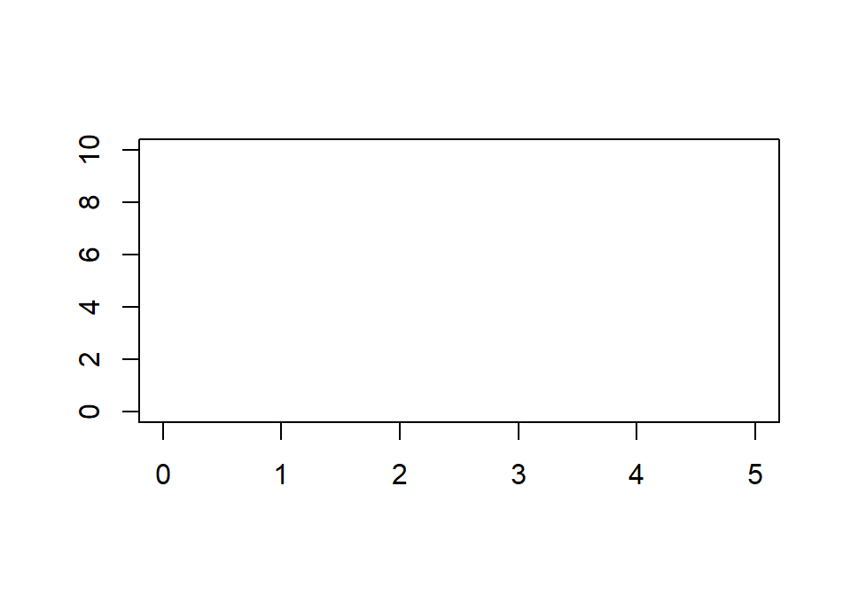

**Task 13:** Now play connect the dots!

This is exactly what `lines()` does.

To do this, we need to reorder the vectors we give to the `x =` and `y =` arguments of `lines()`. Notice that for the line to go from left to right, the points need to be ordered according to its X coordinate from smallest values of X to largest. In other words, we want to know what is the order of the elements of X that sorts X from smallest values to largest. This is exactly what `order()` is for:

```r
z <- sample(100:200, 5)
z
[1] 160 170 126 193 104
# order of elements that sorts z
order(z)
[1] 5 3 1 2 4
# sort z using this order of indices
z[order(z)]
[1] 104 126 160 170 193
```

**Task 14:** At this stage, you might be tempted to pass `x[order(x)]` and `y[order(y)]` to the `x =` and `y =` arguments of `lines()`, respectively. Try it then!

*Hint:* Either create a new blank canvas first, just like you did in Task 7, or use `plot()` with `type = "l"` (lines) argument

**Task 15:** Why did it not work right?

By sorting `x` according to its values and `y` according to its, we’ve jumbled up the [X, Y] pairs so the line doesn’t go through the original points any more. What we need to do is sort both variables according to the values of `x` to preserve the [X, Y] pairs.

**Task 16:** Let’s do it right this time! draw the line connecting all [X, Y] the points in one direction.

NICE!

We can also draw multiple lines at the same time using the `matlines()` function. There is one limitation when using this function – the X coordinates of the sets of points points defining the separate lines must be the same.

Let’s say we want to create a plot like this:

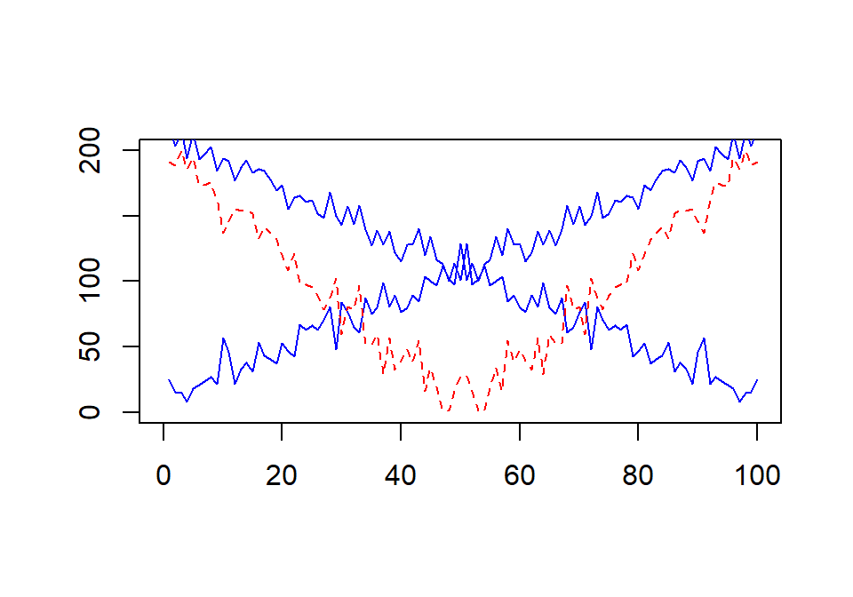

What do we have here? The two blue lines are our original squiggle and its mirror image and the red line is the *absolute* difference between the two. Looks kinda cool, doesn’t it? Let’s get you to create this plot yourself!

**Task 17:** Feel free to try to figure it out yourself if you feel up for a challenge. To get you started, what you need is three sets of Y coordinates – one for each line – and a shared vector of X coordinates. Next, you want to create a matrix of these three Y coordinate vectors. Finally you want to pass the X coordinates and the matrix to the `x =` and `y =` coordinates of `matlines()` respectively, and define the line type `lty =` and colour `col =` arguments with three values each (one for each line).

If you want to try without further hints, go for it. If you’d rather take it step-by-step, the next few subtasks are for you.

**Task 17.1:** First, create a vector `y_orig` containing the Y coordinates of the original line in the correct order – our first blue line.

**Task 17.2:** Next, create a vector `y_mirror` containing the Y coordinates of the mirror-image blue line.

*Hint:* This is just a reversed `y_orig`. If you don’t know how to reverse a vector in `R`, ask the Internet.

**Task 17.3:** Now, create a vector `diff_y` containing the absolute value of the difference between these two. This will include the Y coordinates of the red line

**Task 17.4:** Almost there! You need to **bind** these three vectors by **c**olumn (*nudge, nudge, wink, wink*) into a single matrix. Let’s call it `line_mat`.

**Task 17.5:** Finally, create the empty canvas and add the lines using `matlines()` to it.

*Hint 1:* Remember, `x` has yet to be ordered!

*Hint 2:* The `lty =` argument of `matlines()` can take several values (passed as a vector). You can ask the Internet what the values mean (something like “line types in r lty”)

*Hint 2:* The `col =` argument of `matlines()` can also take several values… Our first two lines are `"blue"` and the third one is… y’know…

You utterly rock!

**What could this possibly be good for**, I hear you ask? Well, see next…

**Task 18:** Try the following (note, using `model` rather than `model2`):

```r
p.exam <- predict(model, schools, interval = "confidence")
head(p.exam)
       fit      lwr      upr
1 58.08451 54.43325 61.73578
2 56.37280 52.97690 59.76870
3 55.34577 51.93063 58.76091
4 59.79623 55.59458 63.99788
5 60.13857 55.80026 64.47688
6 55.34577 51.93063 58.76091
```

You’ll find that `p.exam` is a matrix, consisting of three columns: `fit` is the fitted (predicted) value of exam score on each pupils IQ score; `lwr` and `upper` are the upper and lower bounds of the model confidence interval for each value of `schools$iq`.

Have a look at `?predict.lm` for much more on `predict()` (and, if you feel so inclined, try `?predict` to see where `?predict.lm` comes from!).

**Task 19:** Can you put everything in this section together and recreate the *USEFUL* plot below?

*Hint:* In this figure we have the basic scatterplot between actual `iq` and `exam` values along with the regression line that describes the linear relationship between the two (and the upper and lower estimates at each point).

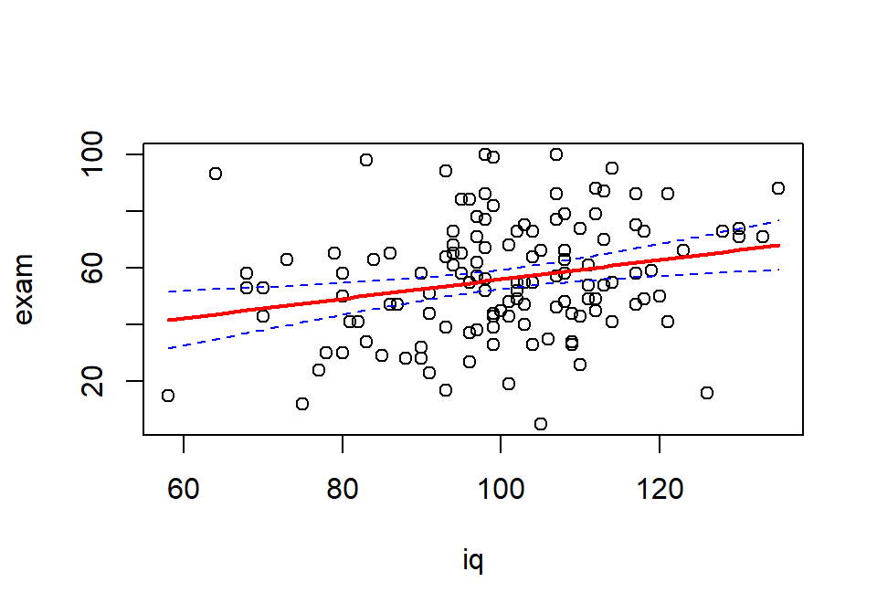

## More on regression

OK, enough doodling, let’s get back to stats!

Earlier on you estimated the effect of IQ on exam performance, and found that there was a modest effect. However, that isn’t the full story: After all of the students in the study had died, Professor Frank N. Stein measured all of their brain volumes, with the idea of discovering whether brain volume was a useful predictor of IQ or of exam performance.

**Task 20:** Load the data for this week from LEARN, and merge it with your existing schools data frame. **Tip:** As the data is already in an `R` format (.Rdata) you can use the `load()` function.

No tricks this week, the merge should be straightforward. Your merged data frame will have an extra column in it now, called `bvol`, for brain volume in cm<sup>3</sup>.

**Task 21:** Does brain volume predict IQ?

**Tip:** You need to build the relevant linear model, using `lm()`

**Task 22:** Are you sure? *i.e.,* is the model appropriate?

**Tip:** Have you looked at your regression model carefully, using some of the model criticism tools you saw in the lecture? Functions you want to think about include `residuals()`, and `plot()` (where `plot()` is called on a linear model object)

**Task 23:** We already know that IQ predicts exam performance, because we tested and graphed the relationship earlier (and in the previous lab). However, does brain volume also predict exam performance? More importantly, does brain volume help predict exam performance *over and above* what IQ already predicts?

**Tip:** You’ll want to test whether adding a new predictor improves on chance (using `anova()`) as part of your answer… *Part 2 of the lecture will help you here.*

#### You have reached your destination!